# Pitcher card

# Kris Bubic

LHP · KC

2026 · 14 G (9 GS) · 882 pitches · Mar 30 – Sep 26, 2026

Independent portfolio sample by Devin Jenkinson, not affiliated with any club. Every number is computed from public Statcast data.

Three big takeaways

1Attack

The 4-seam fastball is the put-away pitch. Use it to finish at-bats.

42% of two-strike pitches · 29% whiffs/swing (63 swings)

It grades 101 Stuff+. No other pitch has 50+ two-strike swings yet.

2Avoid

When behind in the count he throws it 44% of the time; the changeup grades +0.89 there instead.

3Watch

Use the 4-seam fastball up in the zone. It beats the league rate there.

37% whiffs/swing up (94 sw) vs 28% MLB FF up

54% of his 4-seam fastballs finish in the top third. Too few swings down (21) to compare.

Charts

### Movement

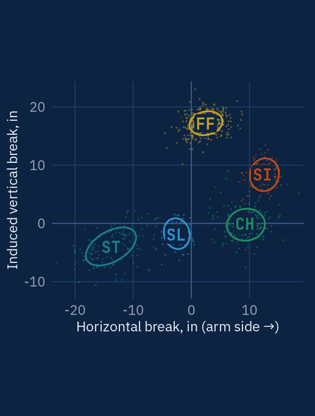

n = 882 pitches. Ellipses hold about 68% of each type; codes sit at the averages.

### Location by count

He throws 53% of pitches in the zone when behind and 40% when ahead.

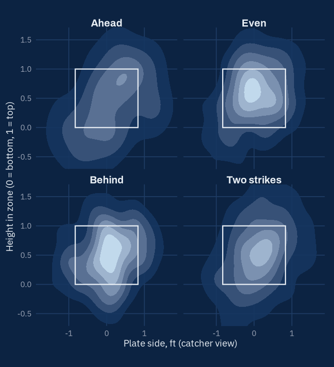

n = 882. Ahead 108 · even 311 · behind 192 · two strikes 271 pitches. Box = rule-book zone.

### Put-away

The FF is 42% of two-strike pitches vs 41% overall.

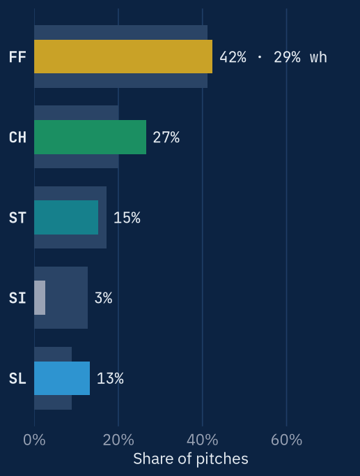

Two-strike n: FF 115, CH 72, ST 41, SL 36, SI 7. Grey bars = overall usage; wh = whiffs per swing (shown with 50+ swings).

### Arsenal

[output not shown]

IVB / HB in inches (HB + = arm side). VAA in degrees at the front of the plate. xRV/100 = expected run value per 100 pitches, pitcher’s view, shrunk with a 250-pitch prior. Stuff+ = this project’s shape-only model (100 = MLB average, 10 = 1 SD).

### Vs. batter hand

| Pitch | LHH # | Use | Whiff | xwOBAcon | RHH # | Use | Whiff | xwOBAcon |
| --- | --- | --- | --- | --- | --- | --- | --- | --- |
| FF | 53 | 25% | – | .189 | 312 | 46% | 23% | .389 |
| CH | 1 | 0% | – | .204 | 180 | 27% | 32% | .214 |
| ST | 50 | 24% | – | .339 | 98 | 15% | – | .284 |
| SI | 64 | 30% | – | .426 | 49 | 7% | – | .317 |
| SL | 43 | 20% | – | .236 | 32 | 5% | – | .276 |

Use = share of pitches to that side. Whiff = whiffs per swing, shown with 50+ swings.